# Coursework Report

*N* removed NAs: 3

*N* removed typo: 1

*N* removed <18: 21

*N* total clean: 125

| Group | *N* | *M*<sub>age</sub> | *M*<sub>rating</sub> |
| --- | --- | --- | --- |
| Control | 71 | 20.31 | 5.80 |
| Experim | 54 | 20.78 | 6.53 |

**Main analysis results**

*t*(123) = -5.08, *p* < .001

[interactive chart not shown]

[figure not shown]

[interactive chart not shown]

# Coursework Report

Analysing Data, Spring 2020

# Methods

## Participants

There were initially 150 participants in this study. 3 participants had to be removed from the sample as they didn’t give their age, whereas 1 other participant’s data had to be removed because they misspelt their age putting “2y”. 21 participants were removed from the data set because they were younger than 18, so for informed consent reasons their results could not be kept (Rupert et al, 1999). Meaning the final number of participants whose data was used was 125. The mean age of the participants in this new set of data was 20.51 years old with a standard deviation of 2.06. The youngest participant was 18 years old while the oldest participant was 27 years old. There were 71 participants in the control condition and 54 participants in the experimental condition.

## Design

The conceptual hypothesis of this study was the question “Does colour influence attractiveness?”

There was an independent categorical variable in this study, which was the colour of the frame in which the 2 pictures were presented to the participant. The two different colours of the frames were white and red. White was the control variable, whilst red was the experimental variable. This was the predictor of the study because depending on which variable the participant was exposed to it was anticipated that this should affect the attractiveness rating that the participants gave the picture. There was also a continuous variable which was the attractiveness rating scale made up of three different questions that the participant was asked;

“How attractive do you think this person is?”;

“How pleasant is this person to look at?”;

“If I were to meet the person in this picture face to face, I would think he is attractive”.

# Results

In the experiment, there were three questions that were labelled ITEM_1, ITEM_2 and ITEM_3 which the participant would rate.

In the control condition of ITEM_2 there was a mean of 5.75 with a standard deviation of 1.43, while in the experimental condition there was a mean of 6.46 with a standard deviation of 1.13.

In the control condition of ITEM_3 the participant answered the question with a mean rating of 5.61 with a standard deviation of 1.18, while in the experimental condition there was a mean of 6.41 with a standard deviation of 1.28.

In the control condition, the mean rating that the participants gave on the attractiveness scales when asked the three questions gave a composite score of 5.80 out of 9 with this result having a standard deviation of 0.85. In the experimental condition, the participant gave the composite score was 6.53 out of 9 with a standard deviation of 0.72. This highlights that in the experimental condition the participant may have been influenced by the red border surrounding the picture which resulted in the participant giving a higher rating on the attractiveness scale. Graph 1 below shows the means in each condition.

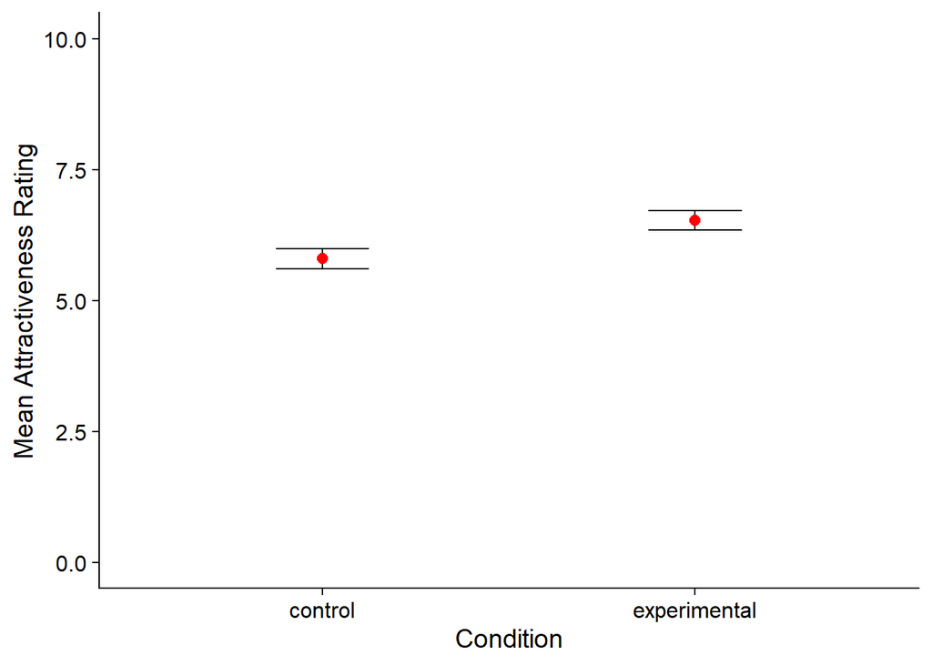

# Discussion

Elliot et al’s (2010) study included 7 sub-experiments which examined the relationship between a red border around a picture and how it can influence women into perceiving the subjects of the pictures as having a higher status and being more attractive. The results of all the experiments came to the same conclusion which was that the colour red did have an effect on how much the participants perceived the subjects of the picture as more attractive. This is important because Elliot’s study highlighted that it was solely the colour red which influenced women into perceiving the picture as more attractive and not any other colour. Elliot suggests that this occurs due to biological and sociological signs that the man has a higher status (Townsend & Levy, 1990) and can also, therefore, have a higher amount of testosterone and better health (Bardin, 1996). Elliot’s findings link to our study because he carried out an extremely similar method, which was presenting an image with different coloured borders and asking questions related to attractiveness and so his results can support our study. It can be concluded that this is an effective method when trying to find out the influence of red on perceived attractiveness and produces significant results, suggesting that our method was sound.

In Prokop’s (2015) study the effect of the woman’s conception risk and how this may have influenced her attractiveness to males was examined. This experiment also used a similar method to our own, presenting a picture to a woman with either a red or grey border surrounding the image of the man. The woman then rated the man on perceived attractiveness after being asked a series of questions. This study came to a mixed conclusion as the first method of a forward counting method to examine the woman’s menstrual cycle did suggest that there was a link between the colour red and the extent of attractiveness felt from the woman towards the man. However, the backwards counting method examining the menstrual cycle didn’t support the hypothesis. This suggests that more research is needed in this area to examine the link between conception risk and women’s attraction towards men in a red setting. However, this experiment uses the same methodology as the current experiment i.e. using different coloured borders followed by a questionnaire, suggesting that this would be a validated method to use when trying to examine the link between red and women’s attraction towards men. However, due to the inconclusive results from Prokop’s experiment, it can’t be determined for certain if there is a link between the conception risk of the woman and how red affects her attraction towards men.

One of the limitations of the current study was the age range studied. The mean age of 20.51 years and an age range from 18- 27 years meaning that it’s only examining the effect of red on women in the younger age range. This is a limitation because other studies have examined the effect of age which highlight that women’s sexual preferences differ as they grow older, which can be due to several factors (Essock, 1989).This could mean that the effect of red on women’s sexual attraction could vary depending on the age of the women and so the study is not fully representative of the effect of red on women and their attraction towards men.

Another limitation of the current study was that there was a lack of replication in the experiment. This is a drawback because it doesn’t show if the experiment is replicable, which is what a good method should have (Kaarlsen, 2014). Replication of the experiment under the same conditions and method should produce similar results in all runs of the experiment, because there is a link between the colour red and women’s perception of men. Therefore, to improve the experiment, it could be repeated by showing the participant multiple images of men, or by using different groups of women the picture.

One potential route for future research is to examine the effect of the woman’s age on how red may affect how attractive she finds men. This could be a good path for future research because evidence shows that as women age their preferences and approaches to sexuality changes (Schwartz, Diefendorf & McGlynn-Wright, 2014). This could be due to a series of factors i.e. biological factors such as fertility which peaks mid-twenties and then begins to decrease (Paris,2017). Psychological factors also play a role, as it has been shown that a woman’s self-perception of herself affects how she views others. Social factors such as the standard of women beauty also affect how high a woman holds her sexuality so this would be an interesting topic to expand on further as it would be suggested that as women get older their attraction to men can change (Gubrium, 2011).

Looking further at factors of how women’s attractiveness to males can vary, the ovulation cycle can also affect women’s attraction to men. It has been seen in chimpanzees that when they are at their highest chance of ovulation, these animals tend to show a preference for males who have a higher status in the group (Gildersleeve et al, 2014). Therefore, taking into account Elliot’s (2010) findings that women perceive men in red as having a higher status, future research could examine how the menstrual cycle could affect women’s perception of men and how the colour red affects their attraction and perception of the man’s perceived status. This research could further build upon Prokop’s (2014) research, however, using a more effective method for tracking the menstrual cycle, for example by keeping a record months before the experiment.

In conclusion, this study aimed to find out whether the colour of the frame surrounding the picture influenced the participant’s attractiveness rating of the image. The main findings were that there was a significant difference between the control and experimental groups and therefore that having a red frame on an image did influence the participant to give higher rating in response to questions on its attractiveness. However, the study may not have been fully representative of the whole population since the mean age range of the participants was very young, and evidence suggests that age does affect attractiveness. The experiment should have been run multiple times to increase its reliability. For future research it could be beneficial to examine this effect of the woman’s age and whether it changes how red can manipulate perceived attractiveness. Another area of future research could be to examine how the menstrual cycle affects the women, as evidence shows that the menstrual cycle can affect the woman’s choice in partner (Gildersleeve et al, 2014).

# References

Bardin, C. W. (1996). *New England Journal of Medicine.*

Essock, S. (1989). Spouse preference shifts with age. *Behavioral and Brain Sciences*, 12(1), 19-20.

Gildersleeve, K., Haselton, Martie G., Fessler, Daniel, Johnson, Kerri, & Robles, Ted. (2014). Meta-analytic and Experimental Investigations of Shifts in Women’s Mate Preferences and Attractiveness across the Ovulatory Cycle, *ProQuest Dissertations and Theses*

Gubrium, A. (2011). “I’ve Lost My Mojo, Baby”. *Sexuality Research & Social Policy*, 8(4), 321-334.

Karlsen, J. (2014). Design and application for a replicable foresight methodology bridging quantitative and qualitative expert data. *European Journal of Futures Research*, 2(1), 1-12.

Paris, W. (2017). LAWS OF ATTRACTION. *Psychology Today*, 50(4), 52-61.

Prokop, P., Pazda, A., & Elliot, A. (2015). Influence of conception risk and sociosexuality on female attraction to male red. *Personality and Individual Differences*, 87, 166-170.

Rupert, P., Kozlowski, N., Hoffman, L., Daniels, D., & Piette, J. (1999). Practical and Ethical Issues in Teaching Psychological Testing. *Professional Psychology: Research and Practice*, 30(2), 209-214.

Schwartz, P., Diefendorf, S., & McGlynn-Wright, A. (2014). Sexuality in aging. *Handbook of sexuality and psychology*, Vol. 1: Person-based approaches. (pp. 523-551). American Psychological Association.

Townsend, J. M., & Levy, G. (1990). *Archives of Sexual Behavior*